# Midterm Code Section

Yueze Xu

2021-03-14

# Instructions

You will need to complete the portion of the exam before starting the second portion. You will use your answers on this exam to complete the second half. Only knitted files will be graded! Make sure your complete this portion of the exam on your own. Use your notes and class examples to get started with the code.

# Abstract

Eventual memory performance is predicted more accurately when a person’s judgment of learning (JOL) is delayed until shortly after studying an item than when made immediately after studying the item. According to the transfer-appropriate-monitoring hypothesis, this delayed- JOL effect arises because of the contextual similarity between the cue for the JOL and the cue for the memory test. In a paired-associate learning experiment, delayed JOLs were cued by the stimulus alone or by the stimulus-response pair, and the eventual test was associative recognition of stimulus-response pairs. Recognition of stimulus-response pairs was predicted more accurately when JOLs had been cued by the stimulus alone than when they had been cued by the stimulus-response pair, even though the latter was more similar than the former to the cue for the recognition test. Implications of these results, especially the lack of support for the class of theories emphasizing transfer-appropriate monitoring, are discussed for theories of the accuracy of JOLs.

# Method

In these experiments, participants are given English word pairs to learn (i.e. dog-table). They are asked after each word pair: “how confident are you that in about ten minutes from now you will be able to recognize the second of the item when prompted with the first? (0 = definitely won’t recognize, 20 = 20% sure, 40 …, 60 …, 80 …, 100 = definitely will recognize). These ratings (JOLs) were given either right after the word pair was presented or after the entire block of word pairs were presented. These ratings were prompted with either just the cue word (i.e. dog, the first word of each pair) or both the words (stimulus-response pairing). After all word-pairs were studied, a 10-minute break was given. Participants were then measured by marking which word-pairings they recognized (0 = not studied, 20 = 20 % sure studied, 40 …, 60 …, 80 …, 100 = definitely studied). You can assume the ratings are continuous.

# Dataset:

- JOL group: if they rated their confidence immediately or at the end of each block for how well they would remember the word-pairs.
- Type cue: what type of cue they were using to rate their confidence, either the word-pair or the cue word only.
- Confidence: their average rated confidence to remember word pairs across trial blocks.
- Recognition: their average memory for words across trial blocks.

In this section, the data will be loaded for you from the package. You will change the id = 123456 to your HU id number. This number will generate your data for you in the same time each way, so if you rerun this analysis, you will get the same numbers each time.

```r
library(learnSTATS)
library(mice, quietly = T)
```

```r
library(corrplot)
midterm <- midterm_data(idnum = 285987)
head(midterm)
```

```
##   JOL_group type_cue    conf1    conf2    conf3    conf4    conf5    conf6
## 1   delayed cue only 47.92823 54.27069 50.69000 33.19729 52.68285 48.54287
## 2   delayed cue only 59.11762 56.77388 47.38625 52.15854 49.77405 56.57754
## 3   delayed cue only 29.10023 37.37647 31.85353 54.83226 45.42613 63.37597
## 4   delayed cue only 46.16137 62.03636 40.13936 39.22199 50.15157 53.49193
## 5   delayed cue only 33.96787 34.04133 52.00739 30.93668 48.94144 38.20364
## 6   delayed cue only 42.51239 60.08519 44.89308 43.26911 48.10865 46.21736
##      conf7    conf8    conf9   conf10     rec1     rec2     rec3     rec4
## 1 36.08464 56.25872 56.59004 56.71015 64.22978 62.79253 67.97973 65.98951
## 2 45.69143 64.32464 38.48769 40.81605 54.95167 61.39283 65.46013 61.94875
## 3 57.40386 52.39441 41.52758 44.95378 56.22560 62.74600 69.60559 63.62578
## 4 61.51931 49.19468 53.71160 59.93081 58.76720 63.38913 45.92342 59.92817
## 5 39.38256 67.71461 71.36177 60.14172 69.56622 71.26031 60.25422 52.15515
## 6 30.92301 61.36020 47.68155 47.57914 64.81650 70.56299 55.64212 63.30245
##       rec5     rec6     rec7     rec8     rec9    rec10
## 1 58.48388 24.41187 52.56711 44.96937 58.90294 53.24454
## 2 51.00686 69.65785 62.19389 61.95185 63.49806       NA
## 3 64.36421 48.15363 60.25412 53.61177 57.24864 62.88578
## 4       NA 66.09681 64.87661 63.36250 52.92703 63.85315
## 5 65.30355 76.94038 61.57742 65.61202 55.47881 59.93665
## 6 52.12033 44.51027 63.29992 57.69619 61.55183 61.84048
```

# Data screening:

## Accuracy:

```r
summary(midterm)
```

```
##   JOL_group           type_cue             conf1           conf2
##  Length:204         Length:204         Min.   :25.93   Min.   :12.13
##  Class :character   Class :character   1st Qu.:42.23   1st Qu.:44.41
##  Mode  :character   Mode  :character   Median :48.94   Median :50.95
##                                        Mean   :49.02   Mean   :50.65
##                                        3rd Qu.:55.39   3rd Qu.:57.49
##                                        Max.   :72.73   Max.   :89.29
##                                        NA's   :6       NA's   :6
##      conf3           conf4            conf5           conf6
##  Min.   :24.44   Min.   :-5.754   Min.   :19.25   Min.   :26.31
##  1st Qu.:43.45   1st Qu.:39.924   1st Qu.:45.56   1st Qu.:41.14
##  Median :50.00   Median :49.458   Median :50.59   Median :49.24
##  Mean   :49.32   Mean   :47.634   Mean   :50.81   Mean   :50.02
##  3rd Qu.:55.68   3rd Qu.:55.718   3rd Qu.:56.79   3rd Qu.:57.58
##  Max.   :72.31   Max.   :88.535   Max.   :79.73   Max.   :82.49
##  NA's   :6       NA's   :6        NA's   :6       NA's   :6
##      conf7           conf8           conf9           conf10
##  Min.   :17.25   Min.   :23.38   Min.   :18.32   Min.   :-108.86
##  1st Qu.:43.29   1st Qu.:44.08   1st Qu.:41.83   1st Qu.:  42.37
##  Median :49.09   Median :50.94   Median :48.56   Median :  50.39
##  Mean   :49.01   Mean   :50.77   Mean   :49.38   Mean   :  51.15
##  3rd Qu.:55.70   3rd Qu.:57.18   3rd Qu.:56.51   3rd Qu.:  60.09
##  Max.   :73.89   Max.   :77.57   Max.   :88.53   Max.   : 218.00
##  NA's   :6       NA's   :6       NA's   :6       NA's   :6
##       rec1            rec2            rec3            rec4
##  Min.   :48.06   Min.   :42.32   Min.   :45.92   Min.   :47.07
##  1st Qu.:57.11   1st Qu.:56.77   1st Qu.:56.15   1st Qu.:57.19
##  Median :60.40   Median :60.30   Median :59.74   Median :59.97
##  Mean   :60.49   Mean   :60.03   Mean   :59.50   Mean   :59.92
##  3rd Qu.:63.83   3rd Qu.:63.38   3rd Qu.:62.73   3rd Qu.:63.06
##  Max.   :79.98   Max.   :74.64   Max.   :71.25   Max.   :71.33
##  NA's   :6       NA's   :6       NA's   :6       NA's   :6
##       rec5             rec6            rec7            rec8
##  Min.   : 15.82   Min.   :24.41   Min.   :47.85   Min.   :44.97
##  1st Qu.: 54.86   1st Qu.:55.42   1st Qu.:55.67   1st Qu.:57.02
##  Median : 58.46   Median :59.69   Median :59.54   Median :59.40
##  Mean   : 57.84   Mean   :59.62   Mean   :59.56   Mean   :59.89
##  3rd Qu.: 62.79   3rd Qu.:64.61   3rd Qu.:63.54   3rd Qu.:63.08
##  Max.   :111.62   Max.   :98.62   Max.   :72.63   Max.   :73.01
##  NA's   :6        NA's   :6       NA's   :6       NA's   :6
##       rec9           rec10
##  Min.   :40.32   Min.   :43.02
##  1st Qu.:55.26   1st Qu.:56.40
##  Median :59.47   Median :59.66
##  Mean   :59.48   Mean   :59.33
##  3rd Qu.:63.66   3rd Qu.:62.85
##  Max.   :73.01   Max.   :70.28
##  NA's   :6       NA's   :6
```

```r
notypos <- midterm
str(notypos)
```

```
## 'data.frame':    204 obs. of  22 variables:
##  $ JOL_group: chr  "delayed" "delayed" "delayed" "delayed" ...
##  $ type_cue : chr  "cue only" "cue only" "cue only" "cue only" ...
##  $ conf1    : num  47.9 59.1 29.1 46.2 34 ...
##  $ conf2    : num  54.3 56.8 37.4 62 34 ...
##  $ conf3    : num  50.7 47.4 31.9 40.1 52 ...
##  $ conf4    : num  33.2 52.2 54.8 39.2 30.9 ...
##  $ conf5    : num  52.7 49.8 45.4 50.2 48.9 ...
##  $ conf6    : num  48.5 56.6 63.4 53.5 38.2 ...
##  $ conf7    : num  36.1 45.7 57.4 61.5 39.4 ...
##  $ conf8    : num  56.3 64.3 52.4 49.2 67.7 ...
##  $ conf9    : num  56.6 38.5 41.5 53.7 71.4 ...
##  $ conf10   : num  56.7 40.8 45 59.9 60.1 ...
##  $ rec1     : num  64.2 55 56.2 58.8 69.6 ...
##  $ rec2     : num  62.8 61.4 62.7 63.4 71.3 ...
##  $ rec3     : num  68 65.5 69.6 45.9 60.3 ...
##  $ rec4     : num  66 61.9 63.6 59.9 52.2 ...
##  $ rec5     : num  58.5 51 64.4 NA 65.3 ...
##  $ rec6     : num  24.4 69.7 48.2 66.1 76.9 ...
##  $ rec7     : num  52.6 62.2 60.3 64.9 61.6 ...
##  $ rec8     : num  45 62 53.6 63.4 65.6 ...
##  $ rec9     : num  58.9 63.5 57.2 52.9 55.5 ...
##  $ rec10    : num  53.2 NA 62.9 63.9 59.9 ...
```

```r
notypos$JOL_group <- factor(notypos$JOL_group,
                      levels = c("delayed", "immediate"),
                      labels = c("Delayed", "Immediate"))
notypos$type_cue <- factor(notypos$type_cue,
                      levels = c("cue only", "stimulus pairs"),
                      labels = c("Cue only", "Stimulus pairs"))

str(notypos$JOL_group)
```

```
##  Factor w/ 2 levels "Delayed","Immediate": 1 1 1 1 1 1 1 1 1 1 ...
```

```r
table(notypos$JOL_group)
```

```
##
##   Delayed Immediate
##       102       102
```

```r
str(notypos$type_cue)
```

```
##  Factor w/ 2 levels "Cue only","Stimulus pairs": 1 1 1 1 1 1 1 1 NA 1 ...
```

```r
table(notypos$type_cue)
```

```
##
##       Cue only Stimulus pairs
##             98            100
```

```r
notypos[ , 3:22][ notypos[ , 3:22] < 0 ] <- NA
notypos[ , 3:22][ notypos[ , 3:22] > 100 ] <- NA

summary(notypos)
```

```
##      JOL_group             type_cue       conf1           conf2
##  Delayed  :102   Cue only      : 98   Min.   :25.93   Min.   :12.13
##  Immediate:102   Stimulus pairs:100   1st Qu.:42.23   1st Qu.:44.41
##                  NA's          :  6   Median :48.94   Median :50.95
##                                       Mean   :49.02   Mean   :50.65
##                                       3rd Qu.:55.39   3rd Qu.:57.49
##                                       Max.   :72.73   Max.   :89.29
##                                       NA's   :6       NA's   :6
##      conf3           conf4            conf5           conf6
##  Min.   :24.44   Min.   : 6.162   Min.   :19.25   Min.   :26.31
##  1st Qu.:43.45   1st Qu.:40.002   1st Qu.:45.56   1st Qu.:41.14
##  Median :50.00   Median :49.472   Median :50.59   Median :49.24
##  Mean   :49.32   Mean   :47.905   Mean   :50.81   Mean   :50.02
##  3rd Qu.:55.68   3rd Qu.:55.756   3rd Qu.:56.79   3rd Qu.:57.58
##  Max.   :72.31   Max.   :88.535   Max.   :79.73   Max.   :82.49
##  NA's   :6       NA's   :7        NA's   :6       NA's   :6
##      conf7           conf8           conf9           conf10
##  Min.   :17.25   Min.   :23.38   Min.   :18.32   Min.   : 4.377
##  1st Qu.:43.29   1st Qu.:44.08   1st Qu.:41.83   1st Qu.:43.943
##  Median :49.09   Median :50.94   Median :48.56   Median :50.183
##  Mean   :49.01   Mean   :50.77   Mean   :49.38   Mean   :49.799
##  3rd Qu.:55.70   3rd Qu.:57.18   3rd Qu.:56.51   3rd Qu.:56.994
##  Max.   :73.89   Max.   :77.57   Max.   :88.53   Max.   :78.026
##  NA's   :6       NA's   :6       NA's   :6       NA's   :40
##       rec1            rec2            rec3            rec4
##  Min.   :48.06   Min.   :42.32   Min.   :45.92   Min.   :47.07
##  1st Qu.:57.11   1st Qu.:56.77   1st Qu.:56.15   1st Qu.:57.19
##  Median :60.40   Median :60.30   Median :59.74   Median :59.97
##  Mean   :60.49   Mean   :60.03   Mean   :59.50   Mean   :59.92
##  3rd Qu.:63.83   3rd Qu.:63.38   3rd Qu.:62.73   3rd Qu.:63.06
##  Max.   :79.98   Max.   :74.64   Max.   :71.25   Max.   :71.33
##  NA's   :6       NA's   :6       NA's   :6       NA's   :6
##       rec5            rec6            rec7            rec8
##  Min.   :15.82   Min.   :24.41   Min.   :47.85   Min.   :44.97
##  1st Qu.:54.78   1st Qu.:55.42   1st Qu.:55.67   1st Qu.:57.02
##  Median :58.43   Median :59.69   Median :59.54   Median :59.40
##  Mean   :57.56   Mean   :59.62   Mean   :59.56   Mean   :59.89
##  3rd Qu.:62.76   3rd Qu.:64.61   3rd Qu.:63.54   3rd Qu.:63.08
##  Max.   :93.85   Max.   :98.62   Max.   :72.63   Max.   :73.01
##  NA's   :7       NA's   :6       NA's   :6       NA's   :6
##       rec9           rec10
##  Min.   :40.32   Min.   :43.02
##  1st Qu.:55.26   1st Qu.:56.40
##  Median :59.47   Median :59.66
##  Mean   :59.48   Mean   :59.33
##  3rd Qu.:63.66   3rd Qu.:62.85
##  Max.   :73.01   Max.   :70.28
##  NA's   :6       NA's   :6
```

## Missing data:

- Using the 5% rule, exclude all rows that have missing data.
- Create separate datasets for your continuous measures and categorical measures. **I did not create two new datasets for the two type of variables, I use column number [3:22] for continuous variabels, and [1:2] for catergorical variabel, which is JOL group and type_cue.**
- Estimate the missing data for your continuous measures.
- Combine your categorical columns back to your newly estimated continuous columns.

```r
percentmiss <- function(x) { sum(is.na(x))/length(x) * 100}
#rows
missing <- apply(notypos, 1, percentmiss)
table(missing)
```

```
## missing
##                0 4.54545454545455 9.09090909090909 13.6363636363636
##               90               78               27                6
## 18.1818181818182
##                3
```

```r
replacerows <- subset(notypos, missing <= 5)
norows <- subset(notypos, missing > 5)

nrow(notypos)
```

```
## [1] 204
```

```r
nrow(replacerows)
```

```
## [1] 168
```

```r
nrow(norows)
```

```
## [1] 36
```

```r
#columns
apply(replacerows, 2, percentmiss)
```

```
##  JOL_group   type_cue      conf1      conf2      conf3      conf4      conf5
##  0.0000000  1.7857143  2.3809524  0.5952381  1.7857143  1.1904762  1.1904762
##      conf6      conf7      conf8      conf9     conf10       rec1       rec2
##  2.3809524  1.7857143  2.3809524  1.7857143 11.9047619  1.1904762  1.7857143
##       rec3       rec4       rec5       rec6       rec7       rec8       rec9
##  2.3809524  1.7857143  2.9761905  2.3809524  1.1904762  0.5952381  1.1904762
##      rec10
##  1.7857143
```

```r
#take out categorical columns
replacecols <- replacerows[ , c(3:22)]
nocols <- replacerows[ , -c(3:22)]

tempnomiss <- mice(replacecols)
nomiss <- complete(tempnomiss, 1)

dim(notypos)
```

```
## [1] 204  22
```

```r
dim(nomiss)
```

```
## [1] 168  20
```

```r
summary(nomiss)
```

```
##      conf1           conf2           conf3           conf4
##  Min.   :25.93   Min.   :12.13   Min.   :24.44   Min.   : 7.054
##  1st Qu.:42.24   1st Qu.:43.93   1st Qu.:43.19   1st Qu.:40.216
##  Median :49.18   Median :50.16   Median :48.70   Median :49.219
##  Mean   :49.09   Mean   :50.51   Mean   :48.63   Mean   :48.122
##  3rd Qu.:55.42   3rd Qu.:58.12   3rd Qu.:55.70   3rd Qu.:55.246
##  Max.   :71.98   Max.   :89.29   Max.   :70.70   Max.   :88.535
##      conf5           conf6           conf7           conf8
##  Min.   :19.25   Min.   :26.31   Min.   :17.25   Min.   :23.38
##  1st Qu.:46.28   1st Qu.:42.26   1st Qu.:43.03   1st Qu.:43.13
##  Median :51.03   Median :49.16   Median :49.28   Median :50.28
##  Mean   :50.97   Mean   :50.07   Mean   :49.12   Mean   :49.99
##  3rd Qu.:56.88   3rd Qu.:57.56   3rd Qu.:56.39   3rd Qu.:56.89
##  Max.   :79.73   Max.   :81.66   Max.   :73.89   Max.   :77.57
##      conf9           conf10            rec1            rec2
##  Min.   :18.32   Min.   : 4.377   Min.   :48.06   Min.   :46.58
##  1st Qu.:41.75   1st Qu.:44.874   1st Qu.:57.45   1st Qu.:57.07
##  Median :48.53   Median :50.273   Median :60.47   Median :60.53
##  Mean   :49.72   Mean   :50.276   Mean   :60.49   Mean   :60.29
##  3rd Qu.:57.11   3rd Qu.:56.710   3rd Qu.:63.82   3rd Qu.:63.37
##  Max.   :88.53   Max.   :78.026   Max.   :79.98   Max.   :74.64
##       rec3            rec4            rec5            rec6
##  Min.   :45.92   Min.   :47.07   Min.   :25.71   Min.   :24.41
##  1st Qu.:56.11   1st Qu.:57.10   1st Qu.:54.75   1st Qu.:55.49
##  Median :59.74   Median :59.88   Median :58.93   Median :60.29
##  Mean   :59.56   Mean   :60.00   Mean   :57.76   Mean   :59.91
##  3rd Qu.:62.84   3rd Qu.:63.37   3rd Qu.:63.29   3rd Qu.:64.84
##  Max.   :71.25   Max.   :71.33   Max.   :93.85   Max.   :98.62
##       rec7            rec8            rec9           rec10
##  Min.   :47.85   Min.   :44.97   Min.   :45.96   Min.   :43.02
##  1st Qu.:55.19   1st Qu.:57.01   1st Qu.:55.41   1st Qu.:55.91
##  Median :59.04   Median :59.42   Median :59.47   Median :59.56
##  Mean   :59.26   Mean   :59.83   Mean   :59.55   Mean   :59.28
##  3rd Qu.:63.29   3rd Qu.:63.05   3rd Qu.:63.51   3rd Qu.:63.05
##  Max.   :72.32   Max.   :73.01   Max.   :73.01   Max.   :70.28
```

```r
#combine columns
allcolumns <- cbind(nocols,nomiss)
summary(allcolumns)
```

```
##      JOL_group            type_cue      conf1           conf2
##  Delayed  :91   Cue only      :79   Min.   :25.93   Min.   :12.13
##  Immediate:77   Stimulus pairs:86   1st Qu.:42.24   1st Qu.:43.93
##                 NA's          : 3   Median :49.18   Median :50.16
##                                     Mean   :49.09   Mean   :50.51
##                                     3rd Qu.:55.42   3rd Qu.:58.12
##                                     Max.   :71.98   Max.   :89.29
##      conf3           conf4            conf5           conf6
##  Min.   :24.44   Min.   : 7.054   Min.   :19.25   Min.   :26.31
##  1st Qu.:43.19   1st Qu.:40.216   1st Qu.:46.28   1st Qu.:42.26
##  Median :48.70   Median :49.219   Median :51.03   Median :49.16
##  Mean   :48.63   Mean   :48.122   Mean   :50.97   Mean   :50.07
##  3rd Qu.:55.70   3rd Qu.:55.246   3rd Qu.:56.88   3rd Qu.:57.56
##  Max.   :70.70   Max.   :88.535   Max.   :79.73   Max.   :81.66
##      conf7           conf8           conf9           conf10
##  Min.   :17.25   Min.   :23.38   Min.   :18.32   Min.   : 4.377
##  1st Qu.:43.03   1st Qu.:43.13   1st Qu.:41.75   1st Qu.:44.874
##  Median :49.28   Median :50.28   Median :48.53   Median :50.273
##  Mean   :49.12   Mean   :49.99   Mean   :49.72   Mean   :50.276
##  3rd Qu.:56.39   3rd Qu.:56.89   3rd Qu.:57.11   3rd Qu.:56.710
##  Max.   :73.89   Max.   :77.57   Max.   :88.53   Max.   :78.026
##       rec1            rec2            rec3            rec4
##  Min.   :48.06   Min.   :46.58   Min.   :45.92   Min.   :47.07
##  1st Qu.:57.45   1st Qu.:57.07   1st Qu.:56.11   1st Qu.:57.10
##  Median :60.47   Median :60.53   Median :59.74   Median :59.88
##  Mean   :60.49   Mean   :60.29   Mean   :59.56   Mean   :60.00
##  3rd Qu.:63.82   3rd Qu.:63.37   3rd Qu.:62.84   3rd Qu.:63.37
##  Max.   :79.98   Max.   :74.64   Max.   :71.25   Max.   :71.33
##       rec5            rec6            rec7            rec8
##  Min.   :25.71   Min.   :24.41   Min.   :47.85   Min.   :44.97
##  1st Qu.:54.75   1st Qu.:55.49   1st Qu.:55.19   1st Qu.:57.01
##  Median :58.93   Median :60.29   Median :59.04   Median :59.42
##  Mean   :57.76   Mean   :59.91   Mean   :59.26   Mean   :59.83
##  3rd Qu.:63.29   3rd Qu.:64.84   3rd Qu.:63.29   3rd Qu.:63.05
##  Max.   :93.85   Max.   :98.62   Max.   :72.32   Max.   :73.01
##       rec9           rec10
##  Min.   :45.96   Min.   :43.02
##  1st Qu.:55.41   1st Qu.:55.91
##  Median :59.47   Median :59.56
##  Mean   :59.55   Mean   :59.28
##  3rd Qu.:63.51   3rd Qu.:63.05
##  Max.   :73.01   Max.   :70.28
```

```r
#combine rows
allrows <- rbind(allcolumns, norows)
summary(allrows)
```

```
##      JOL_group             type_cue       conf1           conf2
##  Delayed  :102   Cue only      : 98   Min.   :25.93   Min.   :12.13
##  Immediate:102   Stimulus pairs:100   1st Qu.:42.31   1st Qu.:44.46
##                  NA's          :  6   Median :49.02   Median :50.99
##                                       Mean   :49.10   Mean   :50.67
##                                       3rd Qu.:55.39   3rd Qu.:57.47
##                                       Max.   :72.73   Max.   :89.29
##                                       NA's   :2       NA's   :5
##      conf3           conf4            conf5           conf6
##  Min.   :24.44   Min.   : 6.162   Min.   :19.25   Min.   :26.31
##  1st Qu.:43.24   1st Qu.:39.950   1st Qu.:45.65   1st Qu.:41.14
##  Median :49.88   Median :49.472   Median :50.81   Median :49.16
##  Mean   :49.14   Mean   :48.045   Mean   :50.83   Mean   :49.92
##  3rd Qu.:55.66   3rd Qu.:55.860   3rd Qu.:56.77   3rd Qu.:57.43
##  Max.   :72.31   Max.   :88.535   Max.   :79.73   Max.   :82.49
##  NA's   :3       NA's   :5        NA's   :4       NA's   :2
##      conf7           conf8           conf9           conf10
##  Min.   :17.25   Min.   :23.38   Min.   :18.32   Min.   : 4.377
##  1st Qu.:43.25   1st Qu.:44.03   1st Qu.:41.83   1st Qu.:44.350
##  Median :49.11   Median :50.82   Median :48.53   Median :50.183
##  Mean   :48.98   Mean   :50.59   Mean   :49.39   Mean   :49.922
##  3rd Qu.:55.75   3rd Qu.:57.10   3rd Qu.:56.53   3rd Qu.:56.777
##  Max.   :73.89   Max.   :77.57   Max.   :88.53   Max.   :78.026
##  NA's   :3       NA's   :2       NA's   :3       NA's   :20
##       rec1            rec2            rec3            rec4
##  Min.   :48.06   Min.   :42.32   Min.   :45.92   Min.   :47.07
##  1st Qu.:57.12   1st Qu.:56.81   1st Qu.:56.15   1st Qu.:57.35
##  Median :60.42   Median :60.30   Median :59.86   Median :60.01
##  Mean   :60.52   Mean   :60.05   Mean   :59.55   Mean   :59.98
##  3rd Qu.:63.85   3rd Qu.:63.39   3rd Qu.:62.82   3rd Qu.:63.30
##  Max.   :79.98   Max.   :74.64   Max.   :71.25   Max.   :71.33
##  NA's   :4       NA's   :3       NA's   :2       NA's   :3
##       rec5            rec6            rec7            rec8
##  Min.   :15.82   Min.   :24.41   Min.   :47.85   Min.   :44.97
##  1st Qu.:54.69   1st Qu.:55.42   1st Qu.:55.61   1st Qu.:57.03
##  Median :58.46   Median :59.75   Median :59.43   Median :59.42
##  Mean   :57.43   Mean   :59.64   Mean   :59.52   Mean   :59.90
##  3rd Qu.:62.71   3rd Qu.:64.61   3rd Qu.:63.51   3rd Qu.:63.07
##  Max.   :93.85   Max.   :98.62   Max.   :72.63   Max.   :73.01
##  NA's   :2       NA's   :2       NA's   :4       NA's   :5
##       rec9           rec10
##  Min.   :40.32   Min.   :43.02
##  1st Qu.:55.41   1st Qu.:56.30
##  Median :59.28   Median :59.65
##  Mean   :59.47   Mean   :59.28
##  3rd Qu.:63.59   3rd Qu.:62.89
##  Max.   :73.01   Max.   :70.28
##  NA's   :4       NA's   :3
```

## Outliers:

- Calculate your Mahalanobis distance scores.
- Include a summary of your mahal scores that are greater than the cutoff. **From the result, the model include 3 outliers, I have two option of the dataset, one with 2 ouliters, and the other one is 3. (Check the number of outlier from the FALSE result)**

```r
mahal <- mahalanobis(allrows[ , -c(1:2)],
                     colMeans(allrows[ , -c(1:2)], na.rm = T),
                     cov(allrows[ , -c(1:2)], use = "pairwise.complete.obs"))

cutoff <- qchisq(1 - .001, df = ncol(allrows[ , -c(1:2)]))
##how many outliers.
summary(mahal < cutoff)
```

```
##    Mode   FALSE    TRUE    NA's
## logical       3     165      36
```

```r
noout <- subset(allrows, mahal < cutoff)
nrow(noout)
```

```
## [1] 165
```

# Assumptions:

## Additivity:

- Include a `corrplot()` of your continuous measures.

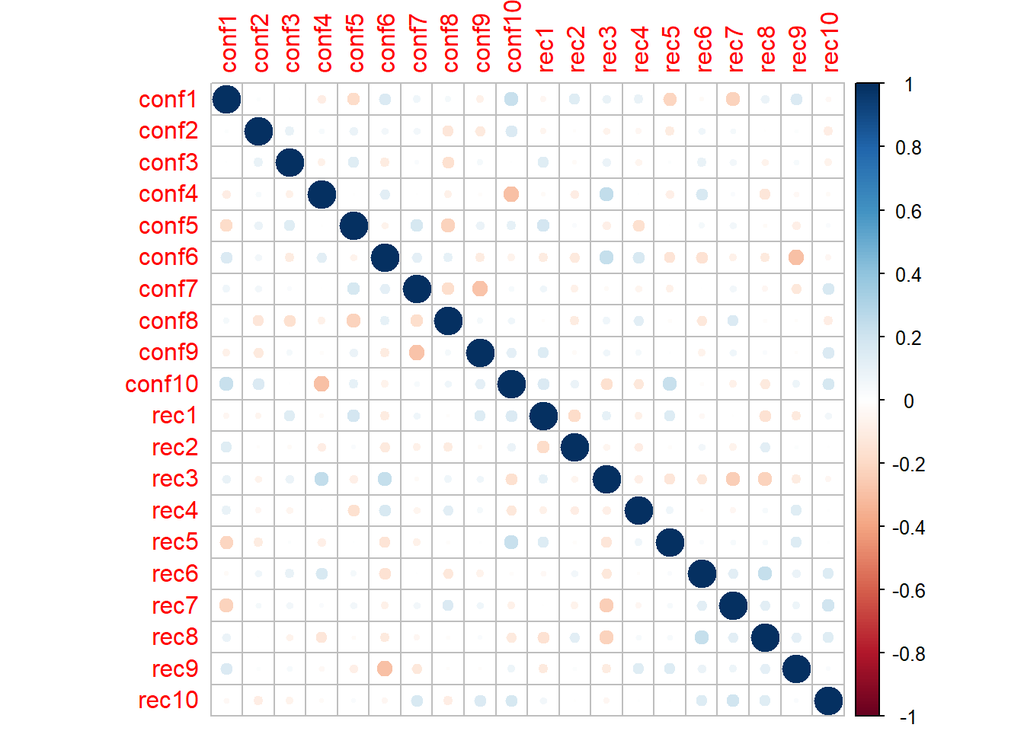

```r
corrplot(cor(noout[ , 3:22]))
```

```r
symnum(cor(noout[ , 3:22]))
```

```
##        cn1 c2 c3 c4 c5 c6 c7 c8 c9 c10 rc1 r2 r3 r4 r5 r6 r7 r8 r9 r10
## conf1  1
## conf2      1
## conf3         1
## conf4            1
## conf5               1
## conf6                  1
## conf7                     1
## conf8                        1
## conf9                           1
## conf10                             1
## rec1                                   1
## rec2                                       1
## rec3                                          1
## rec4                                             1
## rec5                                                1
## rec6                                                   1
## rec7                                                      1
## rec8                                                         1
## rec9                                                            1
## rec10                                                              1
## attr(,"legend")
## [1] 0 ' ' 0.3 '.' 0.6 ',' 0.8 '+' 0.9 '*' 0.95 'B' 1
```

## Linearity:

- Include a picture that shows how you might assess multivariate linearity.

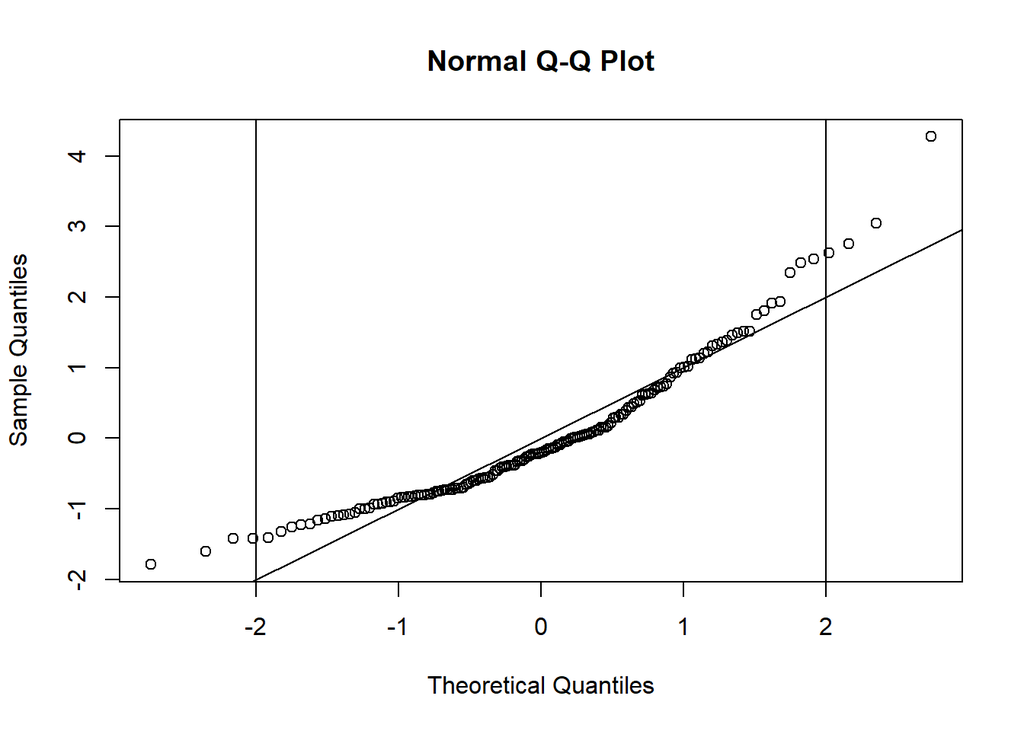

```r
##Fake Regression
random <- rchisq(nrow(noout), 6) # lucky number 6
fake <- lm(random ~ ., data = noout) #drop ID variables
standardized <- rstudent(fake)
fittedvalues <- scale(fake$fitted.values)

{qqnorm(standardized)
  abline(0,1)
  abline(v = -2)
  abline(v = 2)}
```

## Normality:

- Include a picture that shows how you might assess multivariate normality.

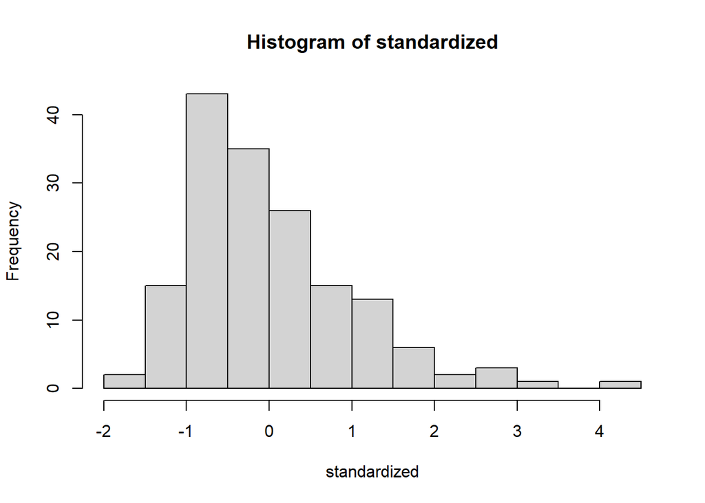

```r
hist(standardized, breaks = 15)
```

## Homogeneity/Homoscedasticity:

- Include a picture that shows how you might assess multivariate homogeneity.

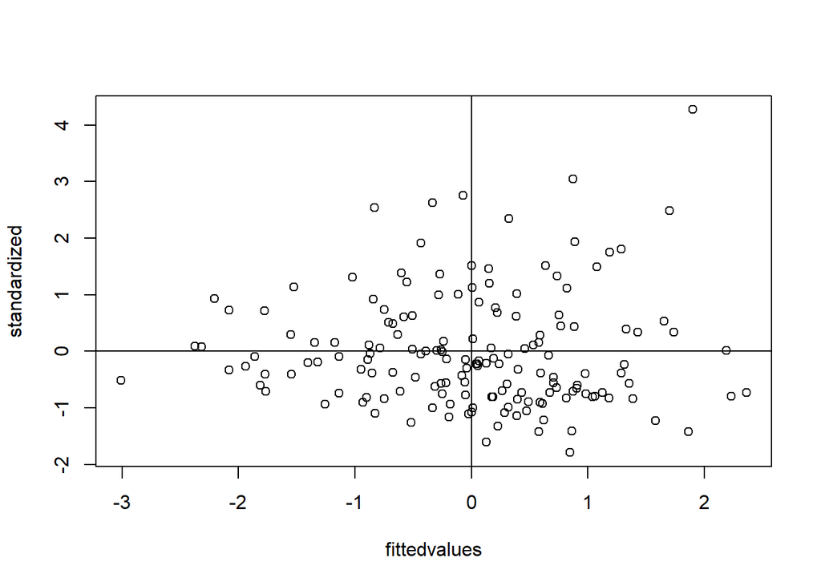

```r
{plot(fittedvalues, standardized)
  abline(h = 0)
  abline(v = 0)}
```

# Data exploration:

Create and save average scores for confidence and recognition across trial blocks (two separate columns). Use the following: `apply(dataset[ , column #s for confidence or recognition], 1, mean)`. You will use these average scores for the rest of the test.

```r
avgconfi <- apply(noout[, 3:12], 1, mean)
avgrec <- apply(noout[, 13:22], 1, mean)
```

Create histograms of the confidence and recognition average scores (you can use hist or ggplot2). These charts do not have to be pretty.

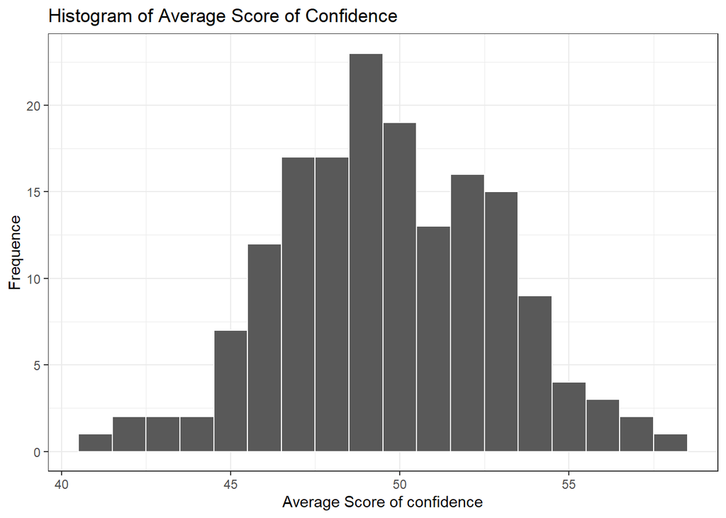

```r
#For confidence
library(ggplot2)
confihist <- ggplot(data = noout, aes(x = avgconfi))
confihist +
  geom_histogram(binwidth = 1, color = 'white') +
  xlab('Average Score of confidence')+
  ylab('Frequence')+
  ggtitle("Histogram of Average Score of Confidence")+
  theme_bw()
```

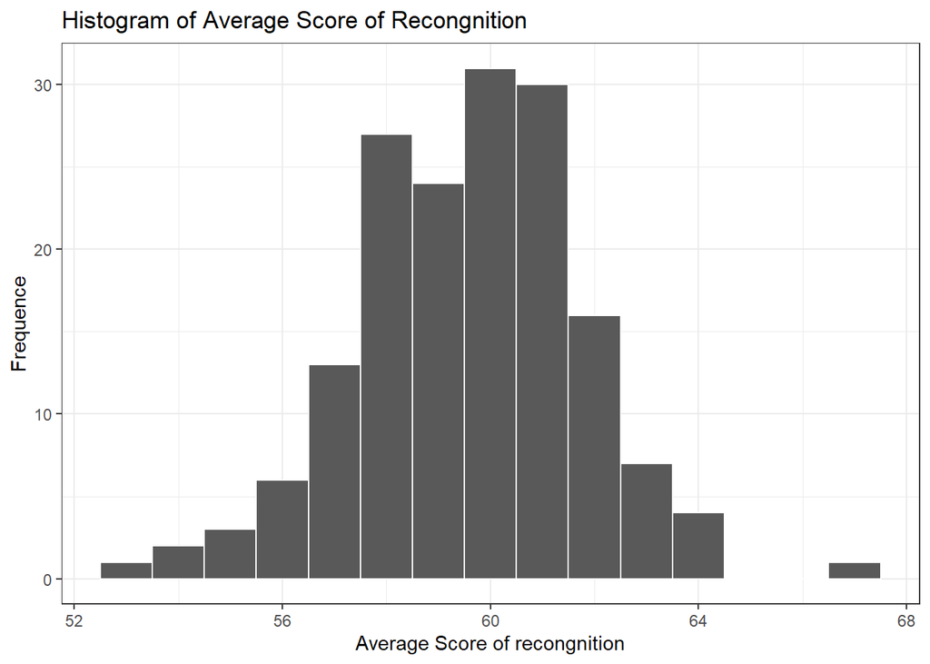

```r
#For recognition
rechist <- ggplot(data = noout, aes(x = avgrec))
rechist +
  geom_histogram(binwidth = 1, color = 'white') +
  xlab('Average Score of recongnition')+
  ylab('Frequence')+
  ggtitle("Histogram of Average Score of Recongnition") +
  theme_bw()
```

Print out the means, standard deviations, and length for each condition (JOL-Group and Type Cue combined together) in the study for recognition only.

```r
des_mean <- tapply(avgrec, list(noout$JOL_group, noout$type_cue), mean, na.rm= T)
des_mean
```

```
##           Cue only Stimulus pairs
## Delayed   59.83777       60.16987
## Immediate 59.76594       58.63576
```

```r
des_std <- tapply(avgrec, list(noout$JOL_group, noout$type_cue), sd, na.rm= T)
des_std
```

```
##           Cue only Stimulus pairs
## Delayed   2.350016       1.395093
## Immediate 1.908805       2.568822
```

```r
des_length <- tapply(avgrec, list(noout$JOL_group, noout$type_cue), length)
des_length
```

```
##           Cue only Stimulus pairs
## Delayed         46             42
## Immediate       30             44
```

Use MOTE to calculate the effect size for the difference between recognition scores for the following comparisons:

```r
library(MOTE)
#1
effect_size1 <- d.ind.t(m1 = des_mean[1,1], m2 = des_mean[2,1],
                        sd1 = des_std[1,1], sd2 = des_std[2,1],
                        n1 = des_length[1,1], n2 = des_length[2,1],a = .05)
effect_size1$d
```

```
## [1] 0.03283318
```

```r
#2
effect_size2 <- d.ind.t(m1 = des_mean[1,2], m2 = des_mean[2,2],
                        sd1 = des_std[1,2], sd2 = des_std[2,2],
                        n1 = des_length[1,2], n2 = des_length[2,2],a = .05)
effect_size2$d
```

```
## [1] 0.7374211
```

# Charts:

On all of these questions, be sure to include a coherent label for the X and Y axes. You should change them to be “professional looking” (i.e. Proper Case, explain the variable listed, and could be printed in a journal). The following will be assessed:

- Is it readable?
- Is X-axis labeled appropriately?
- Is Y-axis labeled appropriately?
- Is it the right graph?
- Do the labels look appropriate?
- Are there error bars when appropriate? bar + Make a bar chart with two independent variables: JOL group, type cue, recognition **For this question specifically, I remove the na rows in variable type_cue, and create a new dataset called nona for barplot only**

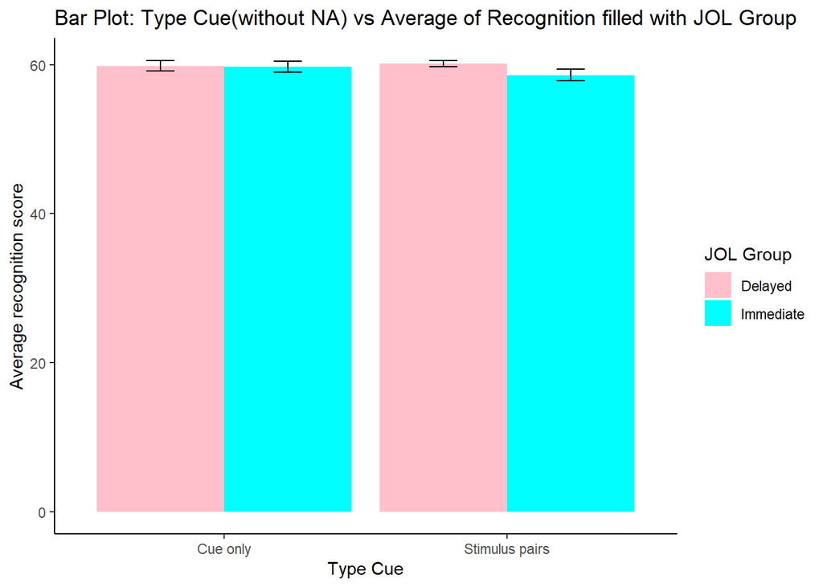

```r
library(ggplot2)

new_noout <- cbind(noout, avgrec)
nona <- subset(new_noout, !is.na(type_cue))
bar <- ggplot(nona, aes(type_cue, avgrec, fill = JOL_group))

bar +
  stat_summary(fun = mean,
               geom = "bar",
               position = "dodge") +
  stat_summary(fun.data = mean_cl_normal,
               geom = "errorbar",
               position = position_dodge(width = 0.90),
               width = .2) +
  xlab("Type Cue") +
  ylab("Average recognition score")+
  scale_fill_manual(name = "JOL Group", labels = c("Delayed", "Immediate"),
                    values = c("Pink", "Cyan")) +
  ggtitle("Bar Plot: Type Cue(without NA) vs Average of Recognition filled with JOL Group") +
  theme_classic()
```

Make a repeated measures bar chart: Type of rating (Confidence, recognition), rating **From this question, I use back the noout dataset, which including the na variables for type_cue.**

```r
library(reshape)
noout$avgconfi <- avgconfi
noout$avgrec <- avgrec
summary(noout)
```

```
##      JOL_group            type_cue      conf1           conf2
##  Delayed  :90   Cue only      :76   Min.   :25.93   Min.   :12.13
##  Immediate:75   Stimulus pairs:86   1st Qu.:42.23   1st Qu.:43.91
##                 NA's          : 3   Median :49.12   Median :49.98
##                                     Mean   :49.04   Mean   :50.41
##                                     3rd Qu.:55.42   3rd Qu.:58.09
##                                     Max.   :71.98   Max.   :89.29
##      conf3           conf4            conf5           conf6
##  Min.   :24.44   Min.   : 7.054   Min.   :19.25   Min.   :26.31
##  1st Qu.:43.16   1st Qu.:40.287   1st Qu.:46.26   1st Qu.:41.73
##  Median :48.72   Median :49.170   Median :50.98   Median :49.07
##  Mean   :48.68   Mean   :48.047   Mean   :50.79   Mean   :49.85
##  3rd Qu.:55.75   3rd Qu.:55.212   3rd Qu.:56.85   3rd Qu.:57.06
##  Max.   :70.70   Max.   :88.535   Max.   :79.73   Max.   :81.66
##      conf7           conf8           conf9           conf10
##  Min.   :17.25   Min.   :23.38   Min.   :18.32   Min.   :12.09
##  1st Qu.:43.05   1st Qu.:43.14   1st Qu.:41.53   1st Qu.:45.39
##  Median :49.27   Median :50.27   Median :48.47   Median :50.43
##  Mean   :49.26   Mean   :49.98   Mean   :49.57   Mean   :50.90
##  3rd Qu.:56.40   3rd Qu.:56.84   3rd Qu.:57.09   3rd Qu.:56.71
##  Max.   :73.89   Max.   :77.57   Max.   :88.53   Max.   :78.03
##       rec1            rec2            rec3            rec4
##  Min.   :48.06   Min.   :46.58   Min.   :45.92   Min.   :47.07
##  1st Qu.:57.48   1st Qu.:57.13   1st Qu.:56.08   1st Qu.:57.14
##  Median :60.47   Median :60.57   Median :59.56   Median :59.88
##  Mean   :60.44   Mean   :60.40   Mean   :59.46   Mean   :60.01
##  3rd Qu.:63.80   3rd Qu.:63.39   3rd Qu.:62.83   3rd Qu.:63.42
##  Max.   :71.12   Max.   :74.64   Max.   :71.25   Max.   :71.33
##       rec5            rec6            rec7            rec8
##  Min.   :25.71   Min.   :24.41   Min.   :47.85   Min.   :44.97
##  1st Qu.:55.10   1st Qu.:55.40   1st Qu.:55.39   1st Qu.:57.04
##  Median :59.12   Median :60.13   Median :59.15   Median :59.43
##  Mean   :57.78   Mean   :59.65   Mean   :59.34   Mean   :59.87
##  3rd Qu.:63.24   3rd Qu.:64.77   3rd Qu.:63.30   3rd Qu.:63.04
##  Max.   :93.85   Max.   :98.62   Max.   :72.32   Max.   :73.01
##       rec9           rec10          avgconfi         avgrec
##  Min.   :45.96   Min.   :43.02   Min.   :41.42   Min.   :53.18
##  1st Qu.:55.48   1st Qu.:55.93   1st Qu.:47.25   1st Qu.:58.26
##  Median :59.42   Median :59.60   Median :49.49   Median :59.59
##  Mean   :59.52   Mean   :59.29   Mean   :49.65   Mean   :59.58
##  3rd Qu.:63.50   3rd Qu.:63.03   3rd Qu.:51.89   3rd Qu.:61.02
##  Max.   :73.01   Max.   :70.28   Max.   :58.18   Max.   :67.15
```

```r
bar2 <- melt(noout, id.vars = c(1:2), measure.vars = c("avgconfi", "avgrec"))
summary(bar2)
```

```
##      JOL_group             type_cue       variable       value
##  Delayed  :180   Cue only      :152   avgconfi:165   Min.   :41.42
##  Immediate:150   Stimulus pairs:172   avgrec  :165   1st Qu.:49.52
##                  NA's          :  6                  Median :55.53
##                                                      Mean   :54.61
##                                                      3rd Qu.:59.58
##                                                      Max.   :67.15
```

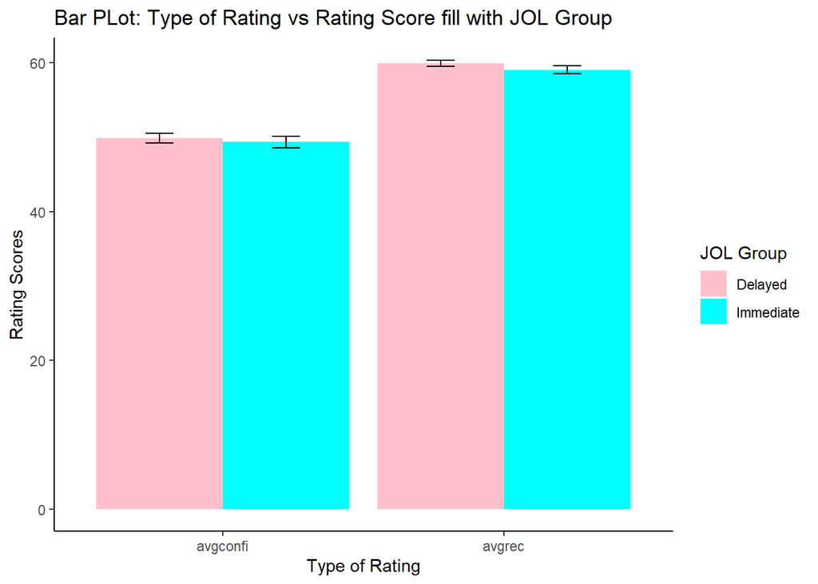

```r
names(bar2)[names(bar2) == 'variable'] <- 'type_of_rating'
names(bar2)[names(bar2) == 'value'] <- 'rating'

barplot2<- ggplot(bar2, aes(type_of_rating,rating, fill = JOL_group))
barplot2 +
  stat_summary(fun = mean,
               geom = "bar",
               position = "dodge") +
  stat_summary(fun.data = mean_cl_normal,
               geom = "errorbar",
               position = position_dodge(width = 0.90),
               width = .2) +
  xlab("Type of Rating") +
  ylab("Rating Scores")+
  scale_fill_manual(name = "JOL Group", labels = c("Delayed", "Immediate"),
                    values = c("Pink", "Cyan")) +
  ggtitle("Bar PLot: Type of Rating vs Rating Score fill with JOL Group") +
  theme_classic()
```

Make a simple scatterplot with a line of best fit: Confidence, recognition

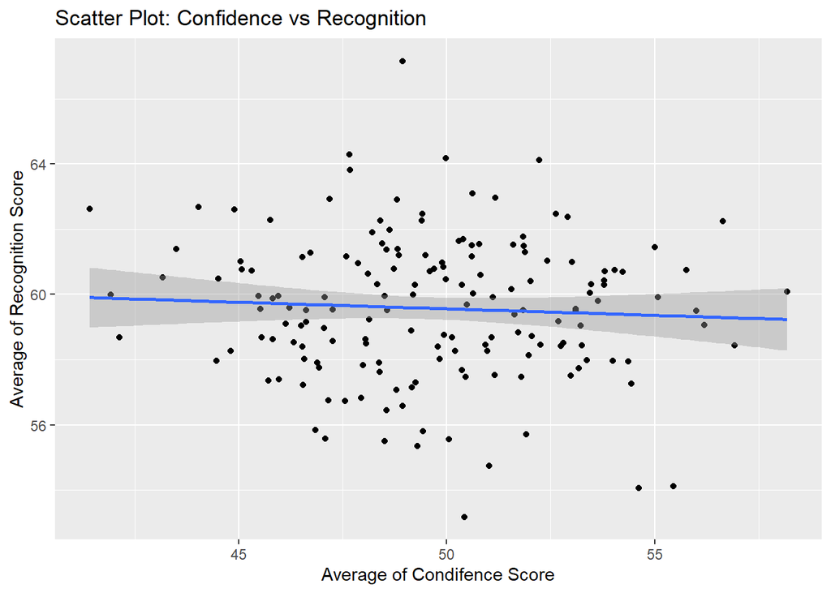

```r
scatter <- ggplot(noout, aes(avgconfi, avgrec))
scatter +
  geom_point() +
  geom_smooth(method = lm) +
  xlab("Average of Condifence Score") +
  ylab("Average of Recognition Score") +
  ggtitle("Scatter Plot: Confidence vs Recognition")
```